# Advanced Visualizations Lecture 03

## 5.2.0 More legend alterations with the `guide` parameter or `guides()` layer

We’ve already looked at some helpful legend alterations pertaining to positioning and text relabeling in section **2.0.0**. Now we’ll explore some of the remaining tips and tricks when it comes to working with multiple legends within your plot.

Recall that within each of the guide types, you can update parameters about text within the legend.

| Component | Sub-components |
| --- | --- |
| title | name, position, theme, hjust, vjust |
| label | name, position, theme, hjust, vjust |
| key | width, height |
| order | you can determine the order of the guide amongst others using integers [1:99]. 0 sets order by an algorithm |
| other | direction of guide, number of rows/cols |

We’ll update the figure in a few ways:

1. We’ll take a closer look at the `order` parameter next using our above visualization of the virus-grouped data.
2. We’ll update the shape and colour legends by altering the labels of each.

```r
### 5.2.0 Alter your guides/legends

respErrorbar.plot +

  # 2. Aesthetics
  ### 5.2.0 Set our guide positions for colour to 1 and size to 2
  guides(shape = guide_legend(title="Virus", order=1),
         colour = guide_legend(title="Virus", order=1),
         size = guide_legend(title="Mean tests performed", order = 2)) +

  # 3. Scaling

  ### 5.2.0 Manually choose the shapes we want to use in our plot for the 2 kinds of data points
  # Set values based on number of levels
  scale_shape_manual(values=c(...),
                     labels = c("Influenza (A+B)", "SARS-CoV-2")) +

  # Set the colour legend
  scale_colour_viridis_d(option = "turbo", begin = 0.1, end = 0.9,
                         labels = c("Influenza (A+B)", "SARS-CoV-2")) +

  # 4. Geoms
  # Add a line to connect our month-virus groups
  geom_line(aes(x=yearMonth,
                y=meanPositivity,
                group = virus,
                colour=virus),
            linewidth=1)
```

```
## Error in eval(expr, envir, enclos): object 'respErrorbar.plot' not found
```

### 5.2.1 Force an override to the legend aesthetics with `override.aes`

Before we leave the `guides()` section, we should update our plot one last time. When you are working with many shapes or squeezed legends, they can sometimes show up a little smaller than you want. You may wish to increase their size on the plot but that may disproportionately increase their size on the legend. If you think about the legend similarly to a plot itself, then you can grasp how the `override.aes` parameter might work.

To adjust some of the aesthetic elements of your plot legend, provide a named `list` to the `override.aes` parameter. You can use `aes` parameters like `size` and `colour` to adjust how your legends display information rather than determining their parameters from the plot itself. We’ll be applying this parameter within our `guides()` layer. However, you could also define this information within a `scale_*` layer as well.

The layer you choose to define the override is up to you, but you should try to centralize certain aspects *where possible* to simplify changes. This applies to many aspects of your plots as well!

```r
# 5.2.1 OVerride legend aesthetics

respErrorbar.plot +
  # 2. Aesthetics
  ### 5.2.1 Update the shape guide to increase the point size
  guides(shape = guide_legend(title="Virus",
                              order=...,
                              override.aes = ...),

         colour = guide_legend(title="Virus",
                               order=...),

         size = guide_legend(title="Mean tests performed", order = ...)) +

  # 3. Scaling
  # Manually choose the shapes we want to use in our plot for the 2 kinds of data points
  # Set values based on number of levels
  scale_shape_manual(values=c(19, 15),
                     labels = c("Influenza (A+B)", "SARS-CoV-2")
                     ) +

  # Set the colour legend
  scale_colour_viridis_d(option = "turbo", begin = 0.1, end = 0.9,
                         labels = c("Influenza (A+B)", "SARS-CoV-2")
                         ) +

  # 4. Geoms
  # Add a line to connect our month-virus groups
  geom_line(aes(x=yearMonth,
                y=meanPositivity,
                group = virus,
                colour=virus),
            linewidth=1)
```

```
## Error in eval(expr, envir, enclos): object 'respErrorbar.plot' not found
```

## 5.3.0 The `ggforce` package annotates with simple `geom_mark_*()` options

The `ggforce()` package brings helpful geoms and functions to `ggplot2` that can quickly annotate groups of data within your plots. These layers work with `ggplot2` like other `geom_*()` layers so you can add them into your plots quite simply. These objects can also accept aesthetics mappings (including the ability to filter groups) amongst many other theme-esque parameters and are added in an automated fashion. More information can be found [here](https://ggforce.data-imaginist.com/reference/index.html)

| geom | Description |
| --- | --- |
| geom_mark_circle() | Add circles to all of your data groups |
| geom_mark_rect() | Add rounded-corner rectangles to your data groups |
| geom_mark_ellipse() | Add ellipses to all of your data groups |
| geom_mark_hull() | Add a more tightly-fitted shape/blob (aka hull) around your data groups |

You can also add custom shapes, specifying their type, location, etc. and extensions to the `facet_*()` group of layers allow you to facet by different columns, zoom in on part of a graph as a facet, and split facets into multiple plots.

Let’s add some ellipses to our plot and exchange our `geom_line()` for a smoother `geom_bspline()`. More about the `geom_bspline()` parameters can be found [here](https://ggforce.data-imaginist.com/reference/geom_bspline.html)

```r
### 5.3.0 Add extra annotations with ggforce

respErrorbar.plot <-

  # Pass the main dataset along
  respFinalPop.df %>%

  # Filter it for only Influenza and SARS
  filter(virus %in% c("Influenza", "SARS-CoV-2"),
         # Remove Canada-wide summary data
         reportingLaboratory != "Canada") %>%

  # Group the data appropriately
  group_by(yearMonth, virus) %>%

  # Calculate summary statistics
  summarise(meanPositivity = mean(percentPositive),
            sdPositivity = sd(percentPositive),
            maxPositivity = max(percentPositive),
            minPositivity = min(percentPositive),
            medPositivity = median(percentPositive),
            meanTests = mean(tests)) %>%

  # Generate your plot object
  ggplot() +
    # 2. Aesthetics
    aes(x = yearMonth, y = meanPositivity,
        # 4.3.0 Move these settings up here, out of the geoms themselves
        colour=virus
        ) +

    # Theme elements
    # Start with a base theme
    lec03.theme +

    # Adjust the x-axis text
    theme(axis.text.x = element_text(angle = 45,  # Rotate 90
                                     hjust = 1,   # Right-justify
                                     vjust = 1)   # Place text at the top, "vertically" on axis tick
    ) +

    # Remember that aesthetics of the same variable must also match legend labels!
    labs(title = "Canada-wide monthly mean positivity of Influenza and SARS-CoV-2 from 2022-2026",
         x = "\nYear",
         y = "Mean percent positivity\n",
         colour = "Virus",
         shape = "Virus",
         size = "Mean tests performed",
         caption = "Notes: 1) SARS-CoV-2 testing was not immediately tracked in the 2022-23 surveillance season.") +

    # Update the shape guide to increase the point size
    guides(shape = guide_legend(title="Virus",
                                order=1,
                                override.aes = list(size=4)),

           colour = guide_legend(title="Virus",
                                 order=1),

           size = guide_legend(title="Mean tests performed", order = 2)) +

    # 3. Scaling

    # Update the y-axis limits
    ylim(NA, 45) +

    # Manually choose the shapes we want to use in our plot for the 2 kinds of data points
    # Set values based on number of levels
    scale_shape_manual(values=c(19, 15),
                       labels = c("Influenza (A+B)", "SARS-CoV-2")
                       ) +

    # Set the colour legend
    scale_colour_viridis_d(option = "turbo", begin = 0.1, end = 0.9,
                           labels = c("Influenza (A+B)", "SARS-CoV-2")
                           ) +

    # 4. Geoms

    # Add a set of errorbars
    geom_errorbar(aes(y = meanPositivity,                           # Set the midpoint
                      ymin = meanPositivity - sdPositivity,         # Set the lower bar
                      ymax = meanPositivity + sdPositivity,         # Set the upper bar
                      colour = virus),                              # Colour based on virus
                  width = 15,
                  linewidth = 1
                  ) +

    geom_point(aes(y = meanPositivity,                           # Add a point at the mean
                   size = meanTests,                             # Base it's size on the mean number of tests
                   colour = virus,                               # Set the colour based on virus
                   shape = virus),
               alpha = 0.7
               ) +

    # Add a line to connect our age groups
    ### 5.3.0 replace our line with a bezier line
    ### this geom is a little smoother and goes through most of the points
    geom_bspline0(aes(group = ..., colour=...),
                 size=1) +

    # This version won't run unless we use an older version of ggforce
    ### 5.3.0 Add ellipses to 2 specific dates to highlight what we care about
    geom_mark_ellipse(aes(group = yearMonth,
                          filter = ... %in% c(as.Date("2023-12-01"), as.Date("2025-02-01")),
                          label=yearMonth),
                      expand = 0.04,
                      fill="blue",
                      alpha=0.2) +

    # Annotations

    # Add rectangles to show different seasons
    annotate("rect", xmin=as.Date("2022-09-01"), xmax=as.Date("2023-08-26"),
             ymin=-Inf, ymax=Inf, fill="orange", alpha=0.1) +

    annotate("rect", xmin=as.Date("2024-08-31"), xmax=as.Date("2025-08-23"),
             ymin=-Inf, ymax=Inf, fill="orange", alpha=0.1) +

    # add a final rectangle and annotate with text
    annotate("rect", xmin=as.Date("2024-06-15"), xmax=as.Date("2024-08-24"),
             ymin=-Inf, ymax=Inf, fill="grey", alpha = 0.5) +

    # Add text to our annotation
    annotate(geom = "text",
             x=as.Date("2024-07-15"),
             y=25,
             label = "Surveillance Gap",
             angle=90, size=10, colour="black") +

    annotate(geom = "text",
             x=as.Date("2025-06-15"),
             y=27,
             label = "Delayed\ninfluenza\npeak",
             angle=0, size=10, colour="black") +

    # Add a curved arrow to our figure
    annotate("curve",                                                 # Make a curve
             x=as.Date("2025-06-15"), xend = as.Date("2025-02-22"),                                     # Set the x-coordinates
             y=36, yend=39.5,                                       # Set the y-coordinates
             lineend = "round", curvature = 0.5,                     # Set the line characteristics
             colour="red", linewidth = 1, arrow = arrow())            # Add an arrow at the end
```

```
## Error in layer(data = data, mapping = mapping, stat = stat, geom = GeomBspline0, : '...' used in an incorrect context
```

```r
# Show the plot
respErrorbar.plot
```

```
## Error in eval(expr, envir, enclos): object 'respErrorbar.plot' not found
```

## 5.4.0 Working with special characters and symbols in your plot text

Working in biological science, you will often find yourself wanting to italicize species names or add special characters when naming proteins etc. This is not a feat easily accomplished using the options provided by `ggplot2`. Instead, you can generate string objects with the required font-changes or symbols and then provide these to objects to your plot. In addition to these special text objects, you could also explore packages that add this kind of functionality more organically to your plots.

### 5.4.1 Use the `expression()` function to generate an expression object

There are a few routes to accomplish this kind of formatting. We’ll explore the first, `expression()` which makes an expression object. The `expression()` function interprets a series of strings and characters into a mathematically-formatted expression. When supplied as an argument, this object is interpreted as a mathematical expression and the output is formatted based on a TeX-like set of rules that parse through the syntax.

Within this function, there are a number of parameters that can *seem* like functions but are implemented within `expression()` rather than using the base R functions - so don’t expect the same kind of behaviours. Here is a non-exhaustive list of potential situations you may encounter.

| Symbol | Description |
| --- | --- |
| +, -, %*%, %/%, %+-% | basic mathematical symbols for +, -, *, /, and $\pm$ |
| paste(x,y,z), x*y*z | juxtapose x, y, and z without any separators |
| sqrt(x) | square root of x |
| sqrt(x, y) | the yth root of x |
| plain(x), bold(x), italic(x), bolditalic(x), symbol(x), underline() | draw x in normal, bold, italic, bolditalic, symbol and underlined font |
| list(x, y, z) | output a comma-separated list of x, y, z |
| hat(x), tilde(x), dot(x), bar(x) | add symbols above x |
| alpha to omega, Alpha to Omega | Greek symbols in lower and upper case |
| infinity | the infinity symbol |
| x ~ y, x ~~ y | put a space between x and y or put extra space between them |
| phantom(0) | leave a gap for “0” without drawing it |
| frac(x, y), over(x, y) | output x over y |
| atop (x, y) | output x over y without any bar |

Note from above, to build your expressions from multiple parts, you should use the * or paste() operators from within `expression()`.

```r
### 5.4.1 using the expression() function to alter font text

respErrorbar.plot +
  ### 5.4.1 alter title labels using the expression() function
  labs(title = expression("Canada-wide monthly"~...("mean positivity")~"of"~bold("Influenza and SARS-CoV-2")~"from 2022-2026"~"\n"),
     y = expression("Mean percent positivity "..." standard deviation"),
     )
```

```
## Error: <text>:6:47: unexpected symbol
## 5:   labs(title = expression("Canada-wide monthly"~...("mean positivity")~"of"~bold("Influenza and SARS-CoV-2")~"from 2022-2026"~"\n"),
## 6:      y = expression("Mean percent positivity "...
##                                                  ^
```

### 5.4.2 Format and interpret variables using `bquote()`

Unlike the `expression()` function, using `bquote()` allows you to reference information which may be stored in *variables* so that you can add these instead of explicitly including the words you want. When thinking about using `bquote()` you can break your math notation into four forms of syntax. These sections or forms can be joined with the ~ symbol.

| Class of text | Syntax | Description |
| --- | --- | --- |
| Strings | “my text” ~ | Words and non-mathematical text that you want to print as-is |
| Math Expressions | infinity, alpha, frac(x, y) | Unquoted and essentially the same kinds of symbols useable by `?plotmath` and `expression()`. |
| Numbers | 1, 42, 900000 | Use unquoted when part of math notation. |
| Variables | **.(**variableName**)** | Used to pass in a string or numeric into your equation. Note the period at the front! |

Many R-enthusiasts prefer this form of generating expressions for it’s flexibility to build whatever you want.

```r
### 5.4.2 using the bquote() function to alter font text

# Quickly use summarise to figure out the min and max number of observations per datapoint
respObsSummary.df <-
  respFinalPop.df %>%
  filter(reportingLaboratory != "Canada",
         virus %in% c("Influenza", "SARS-CoV-2")) %>%
  group_by(yearMonth, virus) %>%
  summarise(observations = n())
# Save the min and max values to variables
... <- respObsSummary.df %>% pull(observations) %>% min()
... <- respObsSummary.df %>% pull(observations) %>% max()


respErrorbar.plot +
  ### 5.4.2 alter title labels using the bquote() function
  labs(title = "Canada-wide monthly"~italic("mean positivity")~"of"~bold("Influenza and SARS-CoV-2")~"from 2022-2026"~"\n",
     y = expression("Mean percent positivity "%+-%" standard deviation"),
     caption = bquote("Total monthly reports: "~.(...)~"-" ~.(...))
     )
```

```
## Error in eval(expr, envir, enclos): object 'respErrorbar.plot' not found
```

### 5.4.3 Use the `ggtext` package to create simple markdown code

As an alternative method to produce simple formatting changes to your text, the `ggtext()` package provides improved text rendering support for `ggplot2`. While this package only supports a limited set of Markdown/HTML/CSS syntax, it can handle simple things like bold and italic text, as well as super- and subscripting.

This package provides 2 new `theme()` elements:

- `element_markdown()`: renders text as markdown/HTML without word wrapping.
- `element_textbox()`: creates a markdown/HTML textbox with word wrapping.

Both of these elements are meant to effectively replace the `element_text()` that is native to `ggplot2`. Let’s alter the x- and y-axis text a little bit to see how this works. Remember we’ll have to replace both our labels and update the `theme()` elements we are interested in.

More information on the `ggtext` package [can be found here](https://github.com/wilkelab/ggtext). Note that this package has not been updated since June 2020 so *caveat emptor*.

```r
# 5.4.3 use the ggtext package for simply markdown

respErrorbar.plot +

  ### 5.4.3 Convert the proper theme elements to markdown
  theme(axis.title.x = ...,
        axis.title.y = ...) +

  ### 5.4.2 alter title labels using the bquote() function
  labs(title = "Canada-wide monthly"~italic("mean positivity")~"of"~bold("Influenza and SARS-CoV-2")~"from 2022-2026"~"\n",
       x = "\n*Date* listed as **start of Month**",
     y = expression("Mean percent positivity..."),
     caption = bquote("1: Errorbars represent mean "~ ''%+-%'' ~"standard deviation with monthly reports of "~.(minObs)~"-" ~.(maxObs)~" observations")
     )
```

```
## Error in eval(expr, envir, enclos): object 'respErrorbar.plot' not found
```

**Which is the best text method for me?** As you can see there are many paths to achieve similar goals. Depending on the complexity of your needs, you may choose one approach over another. Overall **bquote()** is perhaps the most complex to learn and master but the most flexible since it can also parse *variables* as part of its syntax. If you are dealing with simple math expressions, then the **expression()** function could be for you. Utilizing a simpler syntax, it still offers a fair amount of flexibility for creating mathematical expressions. Lastly, if you want to do simple modifications to text title format without much need for equations, then **ggtext** may be the route to go.

## 5.5.0 Marginal plots to visualize relationships and distributions from `ggExtra`

Marginal plots are a very specialized plot type from the `ggExtra` package which combines scatterplot data with distribution data in the margins. The main plot panel has your two variables along the x and y axis. Secondary plots are made on the opposite margins and can be in the form of distribution-based object ie., histograms, boxplots, etc.

The workhorse of this package is the `ggMarginal()` function which takes as input parameters:

- `p`: the ggplot object you would like to add to
- `data`: optional as the information can be drawn from p, otherwise it can be a data.frame object of other data
- `x`: the variable name along the x-axis
- `y`: the variable name along the y-axis
- `type`: the type of marginal plot to show - acceptable types are [density, histogram, boxplot, violin, densigram (histogram/density plot overlay)]
- `margins`: along which margins to show the plots - acceptable inputs are [both, x, y]
- `xparams`, `yparams`: extra parameters to use only for the x or y marginal plots
- `groupColour`, `groupFill`: if `TRUE`, the colour or fill of the marginal plots will be mapped to the aesthetics of the scatterplot

```r
# 5.5.0 generate a marginal plot of 2015 vs 2023 data

respScatter.plot <-

  # Start with the full datasets
  respFinalPop.df %>%
  # Filter it down to a single virus and season
  filter(reportingLaboratory != "Canada",
         virus == "Influenza",
         season == "2024-2025"
         ) %>%

  ggplot() +
  # 2. Aesthetics
  aes(x = tests,
      y = percentPositive,
      colour = reportingLaboratory) +        # Setting a colour is necessary here!

  # Use the standard theme
  lec03.theme +

  # theme(panel.background = element_rect(fill="white", color = NA)) +

  # Move the legend around to within the panel space
  theme(legend.justification = c(1,1),
        legend.position = "bottom",
        legend.direction = "horizontal",
        legend.text = element_text(size = 12)) +

  labs(x = "Tests performed",
       y = "Percent positivity",
       colour = "Province") +

  # 4. Geoms
  # Create a scatterplot
  geom_point(size = 4, alpha = 0.6)


### 5.5.0 Add our marginal boxplots to our graph
respMarginal.plot <- ggMarginal(...,
                                type=..., groupFill=TRUE,
                                margins=..., size=4)
```

```
## Error in eval(expr, envir, enclos): '...' used in an incorrect context
```

```r
# Show the plot
respMarginal.plot
```

```
## Error in eval(expr, envir, enclos): object 'respMarginal.plot' not found
```

```r
ggsave(respMarginal.plot, file = "marginalTest.png")
```

```
## Error in plot_theme(plot): object 'respMarginal.plot' not found
```

**Packages of convenience may come at a cost:** While a package like `ggExtra` provides a convenient way to produce marginal plots, it is a pre-packaged function that can be a little limited. If used correctly, you can make your base plot with all the changes you need and then add your choice of the available marginal plots. It should make a fairly good visualization for low effort as long as you’re happy with its results. This package, not unlike many others, has a slow update schedule with the last two updates being in August 2023 and then September 2025 while a package like `ggplot2` which it relies upon is updated fairly regularly. This discordance can cause certain problems when major revisions occur in a package like `ggplot2` so it’s another situation of *caveat emptor*!

For more information, you can check out more at the [ggExtra cran homepage](https://cran.r-project.org/web/packages/ggExtra/vignettes/ggExtra.html) or [go to the ggExtra GitHub page](https://github.com/daattali/ggExtra).

# 6.0.0 Taking it up a notch

There are many fantastic R packages to analyze and visualize your data. As a group, we are likely working in a variety of specialized areas. The plots we have made so far today should be useful for data exploration for many different kinds of data. In this final section we are going to learn how to arrange multiple plots per page for those publication-ready figures.

## 6.1.0 Multiple plots on one page (ie. for publication images) with `ggarrange()`

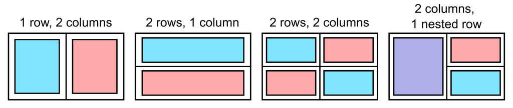

Example plot arrangements that can be accomplished with the `ggpubr` package.

```r
# 6.1.0 make a simply two-row arrangement of plots

# Arrange the two plots in a single page
ggarrange(...,
          ...,
          labels = c("A", "B"),
          ncol = 1, nrow = 2)
```

```
## Error in eval(expr, envir, enclos): '...' used in an incorrect context
```

## 6.2.0 Arrange plots within plots

Next we will add in the boxplot by nesting a `ggarrange()` call within another.

Imagine a square with 4 boxes.

1. We are going to place our line graph across the top row (top 2 boxes)

2. We’ll place our violin plot in the bottom left box

3. We’ll drop our marginal plot into the bottom right box

To do this, we are arranging 2 rows (one with the line graph and one with the [**violin plot + marginal plot**], `nrow = 2`) and we are arranging 2 columns in the bottom row (one with the age group and one with the marginal plot, `ncol = 2`).

```r
# 6.2.0 make a two-row plot, one single item in row 1, 2 items in row 2

# Arrange the two plots in a single page
ggarrange(respLine_annotated.plot, # row 1 plot
          # row 2 plots
          ...(..., ...,
                    labels = c("B", "C"),
                    ncol = 2,
                    nrow = 1
                   ),
          # finish specifying characteristics of the two-row arrangement
          labels = c("A"),
          ncol = 1,
          nrow = 2
         )
```

```
## Error in ggarrange(respLine_annotated.plot, ...(..., ..., labels = c("B", : object 'respLine_annotated.plot' not found
```

## 6.3.0 Small changes can be made with `align` and `font()`

**Problem 1**: for a publication we’ll remove the titles from our plots to save on space. These should be described in our figure legends anyways. For a presentation, however, descriptive titles on plots are usually very helpful. Within `ggarrange()` we can treat the plots much like their own data and keep altering them with the `+` symbol. That means for a quick fix, we *could* just remove the title altogether. Do you remember how to access the plot title? We’ll remove the captions in our lineplot as well since they overlap and crowd the plots.

**Problem 2**: the x-axes in our B/C plots don’t line up well. Would it look better if they did? If y-axis lines or x-axis lines are not aligned, depending on your plots this can be fixed with a call to `align = "v"` or `align="h"`. Usually this attempts to align the borders of your plots, so different representations of x- or y-axis tick marks won’t really fix this.

**Problem 3**: the font labels denoting each plot look a little small overall. We can change this aspect with the `font.labels` parameter.

If you wanted to make sure **all axis titles** are the same size you can specify these small changes using `font()`. You can try to access these attributes through simple names like “axis.title”, and “legend.title” ie `font("axis.title", size=9)` but you need to set *each graph and each attribute separately*. You can also only accomplish this on *`ggplot` objects* and not variants like the `ggExtraPlot` object we created when making our marginal plot. We’d have to go back to the original code the `respMarginal.plot` to achieve that.

Let’s do the following:

- drop our plot A and B titles
- remove the plot A captions
- try to shore up the axes between B and C. Unfortunately we may be stopped by the crowded spacing at the bottom of these plots.
- increase the size of our figure labels

```r
# 6.3.0 make small adjustments to the font and elements of the ggarrange plot

plot <-

# Arrange the two plots in a single page
ggarrange(respLine_annotated.plot + theme(...,
                                             plot.caption = element_blank()), ### 6.3.0 remove the title
          # row 2 plots
          ggarrange(respViolin.plot +
                      theme(plot.title = element_blank()), ### 6.3.0 remove the title
                    respMarginal.plot,
                    labels = c("B", "C"),
                    ncol = 2,
                    nrow = 1,
                    font.label = ..., # make the labels larger
                    align = "h" # Try to align the x-axis of both plots
                   ),
          # finish specifying characteristics of the two-row arrangement
          labels = c("A"),
          ncol = 1,
          nrow = 2,
          font.label = ... # Match the increased label size of the other plots
         )
```

```
## Error in eval(expr, envir, enclos): '...' used in an incorrect context
```

```r
plot
```

```
## function (x, y, ...)
## UseMethod("plot")
## <bytecode: 0x000000000ea41e90>
## <environment: namespace:base>
```

## 6.4.0 Determine significance levels for your plots with `ggpubr`

The `compare_means()` functions has a few relevant parameters to help us out:

- `formula`: the formula we use to define our dependent variable as a function of our independent
- `data`: the data set you will be using
- `method`: the type of comparisons you’d like to make as either comparing means directly (`t.test` or `wilcox.test`) vs omnibus tests (`anova` or `kruskal.test`).
- `ref.group`: a character string or numeric value denoting which group the other comparisons are to be made against (think in terms of a control group!)
- `group.by`: a character vector stating which additional variables you’d like to use in grouping your data. This is used for grouped plots!
- `p.adjust.method`: how you’d like to correct for multiple comparisons (eg. bonferroni, hommel, hochberg, BH, etc)

```r
# 6.4.0 How do `compare_means()` generate comparisons?

respFinalPop.df %>%
  filter(season %in% c("2022-2023", "2025-2026"),
         virus %in% c("SARS-CoV-2")
         ) %>%
  mutate(season = factor(season)) %>%
  # Compare the means of our groups within the data
  compare_means(formula = ...,
                data = .,
                group.by = "reportingLaboratory",
                p.adjust.method = "hochberg")
```

```
## Error in respFinalPop.df %>% filter(season %in% c("2022-2023", "2025-2026"), : '...' used in an incorrect context
```

### 6.4.1 Use `geom_pcw()` to add significance levels to your plots

Now that we’ve seen how `compare_means` generates output, we can use this knowledge to add pairwise comparison significance levels *directly* to our plots using the ggplot-friendly layer `geom_pcw()` which will essentially annotate our plot with the levels.

This function shares many of the same parameters as `compare_means()` with a few additions:

- It does not take a formula but rather generates one based on your aesthetics mappings of `x`, `y` and other factors.
- `mapping`: the same kind of mapping parameters as all other geom layers, this let’s us set some aesthetics - most importantly the `group` aesthetic.
- `y.position`: the y-axis value at which we want to display our significance values. This can be a single value or a vector of values to represent each comparison.
- `method`: here the choice of methods differs and they come from the `rstatix` package including `wilcox_test`, `t_test`, `dunn_test`, and `tukey_hsd`
- `method.args`: a list of additional arguments that are needed for the test method. For instance `tukey_hsd` will require a model object (eg `lm` or `aov`) to determine its comparisons.
- `label`: this determines the source of the labels for your plot. They can include `p.adj`, `p.format`, and `p.signif` as well as an expression using the syntax we have already learned.

There are many additional parameters generally for tweaking *how* the data is displayed. You can find a list of these over on the [ggpubr reference page](https://rpkgs.datanovia.com/ggpubr/reference/geom_pwc.html)

Let’s add the Wilcoxon comparisons from our above analysis directly to our grouped violin plots.

```r
### 6.4.1 Add significance bars to your plots

# Save the updated plot to the original variable
respViolin.plot <-

  respFinalPop.df %>%

  filter(season %in% c("2022-2023", "2025-2026"),
         virus %in% c("SARS-CoV-2")
         ) %>%
  mutate(season = factor(season),
         reportingLaboratory = factor(reportingLaboratory)
         ) %>%
  # Use mutate to move Canada to the end of the factor levels
  mutate(reportingLaboratory = fct_relevel(reportingLaboratory, "Canada", after = Inf)) %>%

  ggplot() +
    # 2. Aesthetics
    aes(x = reportingLaboratory, y = percentPositive) +

    # Start with a base theme
    lec03.theme +
    theme(axis.text.x = element_text(angle = 45, hjust = 1)) +

    # Add labels to our plot
    labs(title = "Distribution of weekly positivity of SARS-CoV-2 across 5 Canadian provinces from 2022-2026",
         x = "\nProvince",
         y = "Percent positivity\n") +

    # Use the guides() layer and get rid of the colour legend
    guides(colour = guide_legend(title = "Surveillance Season (Fall - Summer)", position = "bottom"),
           fill = "none") +

    # 4. Geoms
    # Add a violin plot and fill based on season
    geom_violin(scale="width",
            aes(colour = season,
                fill=after_scale(alpha(colour, 0.3))),
            lwd = 0.5) +

    # Add a boxplot and colour based on season
    geom_boxplot(aes(fill = season),
                 position = position_dodge(width=0.9),
                 width = 0.2,
                 outliers = FALSE) +

    ### 6.4.1 Add in signifcance values to your plot
    # Set the grouping to use stat_group (like group.by)
    geom_pwc(mapping = ...,
             # Use a non-parametric test
             method = ...,
             # Label with significance levels instead of p-values
             label = "p.signif", label.size = 7,
             # Where will your labels go along the y-axis?
             y.position = rep(27, 14),
             )
```

```
## Error in eval(expr, envir, enclos): '...' used in an incorrect context
```

[figure not shown]

```r
# Display the plot
respViolin.plot
```

Now we can simply update our ggarrange plots!

```r
### 6.4.0 Update our final ggpubr plot one last time

plot <-

# Arrange the two plots in a single page
ggarrange(respLine_annotated.plot + theme(plot.title = element_blank(),
                                             plot.caption = element_blank()), ### 6.3.0 remove the title
          # row 2 plots
          ggarrange(respViolin.plot +
                      theme(plot.title = element_blank()), ### 6.3.0 remove the title
                    respMarginal.plot,
                      # theme(plot.background = element_rect(fill="white", color = NA)),
                    labels = c("B", "C"),
                    ncol = 2,
                    nrow = 1,
                    font.label = list(size=20), # make the labels larger
                    align = "h" # Try to align the x-axis of both plots
                   ),
          # finish specifying characteristics of the two-row arrangement
          labels = c("A"),
          ncol = 1,
          nrow = 2,
          font.label = list(size=20) # Match the increased label size of the other plots
         )
```

```
## Error in ggarrange(respLine_annotated.plot + theme(plot.title = element_blank(), : object 'respLine_annotated.plot' not found
```

```r
plot
```

```
## function (x, y, ...)
## UseMethod("plot")
## <bytecode: 0x000000000ea41e90>
## <environment: namespace:base>
```

```r
# Save the plot for yourself
ggsave(filename="Lec03.ggarrange.png", width = 20, height=20, units = "in", dpi = 300)
```

# 7.0.0 Class summary

Today we have *dug deep* into altering and playing with our plots to help get them to that extra level. Although there is far more to explore, this should cover *most* of your needs when it comes to cleaning up your plots. To recap, we’ve looked at:

1. Altering themes and element positions.
2. Controlling/substituting values and labels.
3. Colour palettes.
4. Annotating plots with additional geoms.
5. Text-based formatting changes.
6. Generating Multi-plot figures.
7. Annotating plots with statistical analyses.

## 7.1.0 Weekly assignment

This week’s assignment will be found under the current lecture folder under the “assignment” subfolder. It will include an R markdown notebook that you will use to produce the code and answers for this week’s assignment. Please provide answers in markdown or code cells that immediately follow each question section.

|  | Assignment breakdown |  |
| --- | --- | --- |
| Code | 50% | - Does it follow best practices? |
|  |  | - Does it make good use of available packages? |
|  |  | - Was data prepared properly |
| Answers and Output | 50% | - Is output based on the correct dataset? |
|  |  | - Are groupings appropriate |
|  |  | - Are correct titles/axes/legends correct? |
|  |  | - Is interpretation of the graphs correct? |

Since coding styles and solutions can differ, students are encouraged to use best practices. Assignments *may* be rewarded for well-coded or elegant solutions.

You can save and download the markdown notebook in its native format. Submit this file to the the appropriate assignment section by 9:59am on the date of our next class: March 31st, 2026.

## 7.2.0 Acknowledgements

**Revision 1.0.0**: created and prepared for **CSB1021H S LEC0141**, 03-2021 by Calvin Mok, Ph.D. *Bioinformatician, Education and Outreach, CAGEF.*

**Revision 1.0.1**: edited and prepared for **CSB1020H S LEC0141**, 03-2022 by Calvin Mok, Ph.D. *Bioinformatician, Education and Outreach, CAGEF.*

**Revision 1.0.2**: edited and prepared for **CSB1020H S LEC0141**, 03-2023 by Calvin Mok, Ph.D. *Bioinformatician, Education and Outreach, CAGEF.*

**Revision 2.0.0**: Revised and prepared for **CSB1020H S LEC0141**, 03-2024 by Calvin Mok, Ph.D. *Bioinformatician, Education and Outreach, CAGEF.*

**Revision 3.0.0**: Revised and prepared for **CSB1020H S LEC0141**, 03-2025 by Calvin Mok, Ph.D. *Bioinformatician, Education and Outreach, CAGEF.*

**Revision 4.0.0**: Revised and prepared for **CSB1020H S LEC0141**, 03-2026 by Calvin Mok, Ph.D. *Bioinformatician, Education and Outreach, CAGEF.*

## 7.3.0 References

The R Graph Gallery: https://www.r-graph-gallery.com/index.html

Different aesthetics parameters in `ggplot()`: https://ggplot2.tidyverse.org/reference/aes_group_order.html

Which aesthetics can be altered for different geoms?: https://ggplot2.tidyverse.org/reference/aes_linetype_size_shape.html

Advanced examples of direct labeling with `geom_dl()`: https://directlabels.r-forge.r-project.org/examples.html

More information about the `gghighlight` package: https://cran.r-project.org/web/packages/gghighlight/vignettes/gghighlight.html

Using `expression()`: https://stat.ethz.ch/R-manual/R-devel/library/grDevices/html/plotmath.html

Using `bquote()`: https://www.r-bloggers.com/2018/03/math-notation-for-r-plot-titles-expression-and-bquote/

More options for `ggarrange()`: https://rpkgs.datanovia.com/ggpubr/reference/ggarrange.html

Learning some of the functions for `ggExtra`: https://cran.r-project.org/web/packages/ggExtra/vignettes/ggExtra.html

## The Center for the Analysis of Genome Evolution and Function (CAGEF)

The Centre for the Analysis of Genome Evolution and Function (CAGEF) at the University of Toronto offers comprehensive experimental design, research, and analysis services in microbiome and metagenomic studies, genomics, proteomics, and bioinformatics.

From targeted DNA amplicon sequencing to transcriptomes, whole genomes, and metagenomes, from protein identification to post-translational modification, CAGEF has the tools and knowledge to support your research. Our state-of-the-art facility and experienced research staff provide a broad range of services, including both standard analyses and techniques developed by our team. In particular, we have special expertise in microbial, plant, and environmental systems.

For more information about us and the services we offer, please visit https://www.cagef.utoronto.ca/.

[figure not shown]